# Hyperspectral unmixing of generated spectra from the USGS 1995 Library with outliers using SISAL and MVSA

Author

Louie John M. Rubio

## Motivation:

One of the main goals of hyperspectral unmixing is to obtain separate a composite spectra to its component spectra. For the linear mixing model, the composite spectra is a linear combination of endmember signatures (or archetypes) weighted by their abundance.

From our class readings, minimum volume algorithms, while robust to lack of pure endmember pixels, may not necessarily be robust to outliers and/or noise.

Minimum volume simplex analysis [1] attempts to fit all the points within the simplex, according to the paper. The sensitivity of MVSA to noise can be circumvented by changing the positivity constraints. For the simplex identification via split augmented Lagrangian (SISAL) [2], positivity constraints are changed to make the algorithm more robust to noise/outliers.

In the ParTi website [3], SISAL is described as being indeed robust to outliers, while MVSA is not. We will use the two algorithms to solve the hyperspectral unmixing problem for generated spectra using the USGS 1995 library.

I want to test how well MVSA and SISAL compare to each other when more outliers are introduced to a test dataset.

The code here is based mostly on the `demo_sisal_outliers.comparison` code, and we try to examine what they did in the example. I also added more annotation where there is none. The MVSA used here is the version without changes to the positivity constraints. MVSA and SISAL both use VCA initially to avoid hitting the local minima quickly.

Note that the USGS Library file used is the one included with the demo.

```matlab
cd ~/Desktop/'Grad School Files'/'Second Sem AY 22-23'/'Physics 312'/report/ %Set the directory to run the file
```

### Overview of the code

The sample code has the following inputs if spectra is to be generated from the USGS library.

- `p` is the number of endmembers
- `N` is the number of pixels (with mixed spectra based on combinations of the endmember signatures)
- `SNR` gives the desired signal to noise ratio in decibels
- `MAX_PURITY` sets the maximum “purity” of a pixel. `MAX_PURITY < 1` means there are no pure pixels
- `OUTLIERS` forces pixels to go outside the simple

The generated mixed pixel spectra is handled by the `spectMixGen.m` script.

`M` contains the spectra of the endmembers used to generate the mixed spectra. `L` is the number of bands and `n_materials` is the number of materials from the database.

We first run the code for the case where there are no outliers in the pixel spectra. We will then add outliers for the same set of `M` and see what happens to the endmember extraction.

```matlab
seed = 5;                  % Set RNG seed to make results reproducible

p = 3;                    % Number of endmembers
N = 200;                  % number of pixels
SNR = 100;                % signal-to-noise ratio (E ||y||^2/E ||n||^2) in dBs
SHAPE_PARAMETER  = 1   ;  % uniform over the simplex
MAX_PURITY = 0.8;           % Determines
OUTLIERS  = 0;            % Number of outliers in the data set


load('USGS_1995_Library')

M = select_M(datalib, p, 5);
[L n_materials] = size(datalib);

clear datalib %Remove loaded dataset

function M = select_M(datalib, p, seed)  % Select endmember spectra from data
    rand('seed',seed);

    wavlen=datalib(:,1);    % Wavelengths in microns
    [L n_materials]=size(datalib);
        % select randomly
    sel_mat = 4 + randperm(n_materials-4); %Shuffle indices starting from the 4th column
    sel_mat = sel_mat(1:p); % Select first p items in the shuffled indices

    M = datalib(:,sel_mat);

    clear  wavlen

end
```

This step ensures that the data is in an affine set. In the documentation, Up is an isometric matrix that spans the subspace where Y is (this will be used for projection).

```matlab
randn('seed',5);

% Generate mixed spectra using the spectMixGen function
[Y,x,noise] = spectMixGen(M,N,'Source_pdf', 'Diri_id','pdf_pars',SHAPE_PARAMETER,...
    'max_purity',MAX_PURITY*ones(1,p),'no_outliers',OUTLIERS, ...
    'violation_extremes',[1,1.2],'snr', SNR, ...
    'noise_shape','uniform');
```

```matlab
[Y, Up, my, sing_val] = dataProj(Y,p,'proj_type','affine');
```

```matlab
%--------------------------------------------------------------------------
%        Degree of Difficulty of the problem
%-------------------------------------------------------------------------
%% Compute original subspace
sing_vects = svds(M,p);

% Condition number gives an idea of the difficulty in inferring the subspace
fprintf('Conditioning number of M = %2f \n', sing_vects(1)/sing_vects(end))
% fprintf('\n Hit any key: \n ');
% pause;

Cx = Up'*(M*x)*(M*x)'*Up/N;
Cn = Up'*noise*noise'*Up/N;

[U,D]=svd(Cx);

% Compute the SNR along the direction corresponding the smaller eigenvalue

LOWER_SNR= D(p,p)/(U(:,p)'*Cn*U(:,p));
fprintf('\nSNR along the signal smaller eigenvalue = %f \n', LOWER_SNR);
if LOWER_SNR < 20
    fprintf('\nWARNING: This problem is too hard and the results may be inaccurate \n')
end

clear noise x;
```

```
Conditioning number of M = 72.871851

SNR along the signal smaller eigenvalue = 101287369.846958
```

## SISAL

The implementation of SISAL in MATLAB is in `sisal.m`. The algorithm is initialized with an inflated version of the simplex using VCA. Compared to MVSA, SISAL runs much faster. The plot below shows how the estimated endmembers of SISAL progress with each minimization. We can see that with from very far away, the points forming the simplex move closer and closer.

The `tic` and `toc` lines are used to time the line of code for SISAL, VCA, and MVSA.

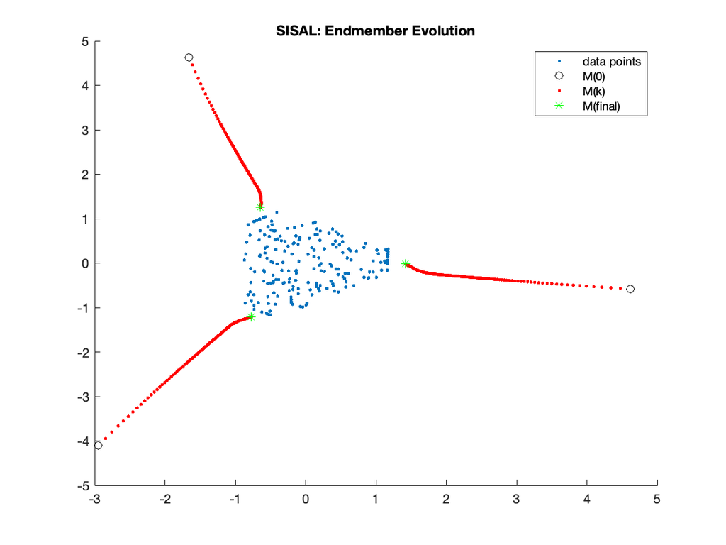

```matlab
%--------------------------------------------------------------------------
%         SISAL[1] -  Simplex identification via split augmented Lagrangian
%-------------------------------------------------------------------------

% start timer
tic
% set the hinge regularization parameter
tau = 0.1;
[A_est] = sisal(Y,p, 'spherize', 'yes','MM_ITERS',40, 'TAU',tau, 'verbose',2);
drawnow;
t(1)=toc;
Msisal =  Up'*A_est;
```

## VCA

VCA is a pure pixel algorithm. Since our test case has no pure pixels, we will see later how it performs. VCA runs fast and uses singular value decomposition. The implementation of VCA is in the `VCA.m` script.

```matlab
%--------------------------------------------------------------------------
%         VCA [5] - Vertex component analysis
%-------------------------------------------------------------------------
%
% start timer
tic
[Ae, indice,ys]= VCA(Y,'Endmembers',p);
Mvca = Up'*Ae;
% stop timer
t(2) = toc;
```

```
SNR estimated = Inf[dB]
... Select proj. to p-1
```

## MVSA

MVSA is a simplex volume minimization algorithm. The implementation of MVSA is in the `mvsa.m` script. This uses harder constraints, which makes it more susceptible to outliers. For the zero outlier case, we don’t expect MVSA to fail catastrophically when finding the endmembers.

```matlab
%--------------------------------------------------------------------------
%         MVSA [4] - Minimum volume simple analysis
%-------------------------------------------------------------------------

%start timer
tic

A_est = mvsa(Y,p,'spherize','yes');
Mvsa = Up'*A_est;

%stop timer
t(3) = toc;
```

```
SNR estimated = 0[dB]
... Select the projective proj.

 iter = 1, f0 = 3.5051, f = 1.4866, exitflag = 1, iter(QP) = 8

 iter = 2, f0 = 1.5065, f = 1.4630, exitflag = 1, iter(QP) = 8

 iter = 3, f0 = 1.4829, f = 1.4630, exitflag = 1, iter(QP) = 8

 iter: = 3 termination test PASSED
```

### Endmember extraction results for SISAL and MVSA (no outliers)

In this first test example, we see that `MVSA` appears to estimate endmembers that appear close to the true endmembers used to create the dataset. `SISAL`’s simplex removes some points and ends up with a smaller simplex than the true and `MVSA` simplex. `VCA` appears to perform the worst (which is a bit expected since it is a pure pixel algorithm).

### Run times

Looking at the run times below, VCA is the fastest, followed by SISAL, with MVSA taking the most time.

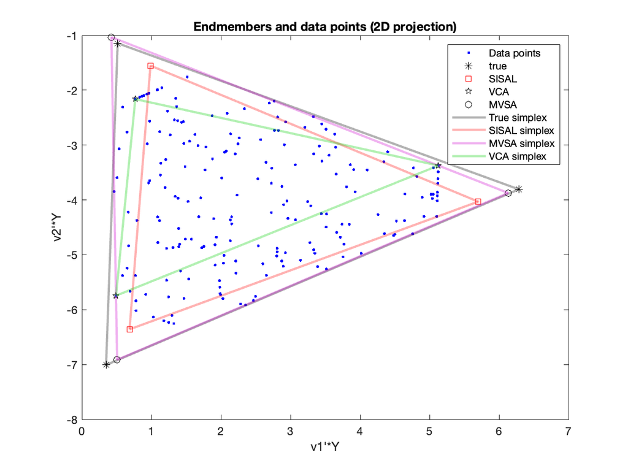

```
TIMES (sec):
 SISAL = 0.63
 MVSA = 1.81
 VCA = 0.02
```

```matlab
%--------------------------------------------------------------------------
%         Project the original mixing matrix and the data set the
%         identified affine set.
%-------------------------------------------------------------------------

Mtrue = Up'*M;
Y = Up'*Y;

%--------------------------------------------------------------------------
%        Display the results
%-------------------------------------------------------------------------

% selects axes  to display
%

I = 1;
J = 2;
K = 3;

% canonical orthogonal directions
E_I = eye(p);

v1 = E_I(:,I);
v2 = E_I(:,J);
v3 = E_I(:,K);

% original axes

Q = inv(Mtrue);
% v1 = Q(I,:)';
% v2 = Q(J,:)';
% v3 = Q(K,:)';

Y = [v1 v2 v3]'*Y;
m_true = [v1 v2 v3]'*Mtrue;
m_sisal = [v1 v2 v3]'*Msisal;


% legend
leg_cell = cell(1);
leg_cell{end} = 'Data points';

H_2 = figure;
plot(Y(1,OUTLIERS+1:end),Y(2,OUTLIERS+1:end),'b.')

hold on;
if OUTLIERS> 0
    plot(Y(1,1:OUTLIERS),Y(2,1:OUTLIERS),'x','Color',[0 0.6 0.6],'LineWidth',3 )
    leg_cell{end +1} = 'OUTLIERS';
end



plot(m_true(1,[1:p 1]), m_true(2,[1:p 1]),'k*')
leg_cell{end +1} = 'true';


plot(m_sisal(1,1:p), m_sisal(2,1:p),'S', 'Color',[1 0 0]) %Plot MVSA endmembers
leg_cell{end +1} = 'SISAL';


m_vca  = [v1 v2 v3]'*Mvca; %Plot VCA endmembers
plot(m_vca(1,[1:p 1]), m_vca(2,[1:p 1]),'p', 'Color',[0  0 0])
leg_cell{end +1} = 'VCA';


m_vsa  = [v1 v2 v3]'*Mvsa; %Plot MVSA endmembers
plot(m_vsa(1,[1:p 1]), m_vsa(2,[1:p 1]),'O','Color',[0 0 0])
leg_cell{end +1} = 'MVSA';


xlabel('v1''*Y'),ylabel('v2''*Y');
legend(leg_cell)
title('Endmembers and data points (2D projection)')

plot(m_true(1,[1:p 1]), m_true(2,[1:p 1]),'k','LineWidth',2, 'DisplayName', 'True simplex', color = [0, 0, 0, 0.3])
plot(m_sisal(1,[1:p 1]), m_sisal(2,[1:p 1]),'r','LineWidth',2, 'DisplayName', 'SISAL simplex', color = [1 0 0 0.3])
plot(m_vsa(1,[1:p 1]), m_vsa(2,[1:p 1]),'LineWidth',2, 'DisplayName', 'MVSA simplex',color = [0.8 0 0.8 0.3])
plot(m_vca(1,[1:p 1]), m_vca(2,[1:p 1]),'LineWidth',2, 'DisplayName', 'VCA simplex',color = [0 0.8 0 0.3])

fprintf('\nTIMES (sec):\n SISAL = %3.2f\n MVSA = %3.2f\n VCA = %3.2f\n', t(1),t(3),t(2))
```

### Mean squared error

Comparing the estimated endmembers, for the case with no outliers, MVSA has a smaller MSE. This is also apparent in the previous figure with MVSA having the closest simplex to the true set of endmembers.

```matlab
%--------------------------------------------------------------------------
%        Display errors
%-------------------------------------------------------------------------

%% alignament
% soft

angles = Mtrue'*Msisal./(repmat(sqrt(sum(Mtrue.^2)),p,1)'.*(repmat(sqrt(sum(Msisal.^2)),p,1)));
P = zeros(p);
for i=1:p
    [dummy,j] = max(angles(i,:));
    P(j,i) = 1;
    angles(:,j) = -inf;
end
% permute colums
Msisal = Msisal*P;
SISAL_ERR =norm(Mtrue-Msisal,'fro')/norm(Mtrue,'fro');


angles = Mtrue'*Mvca./(repmat(sqrt(sum(Mtrue.^2)),p,1)'.*(repmat(sqrt(sum(Mvca.^2)),p,1)));
P = zeros(p);
for i=1:p
    [dummy,j] = max(angles(i,:));
    P(j,i) = 1;
    angles(:,j) = -inf;
end
% permute colums
Mvca = Mvca*P;

VCA_ERR =norm(Mtrue-Mvca,'fro')/norm(Mtrue,'fro');



angles = Mtrue'*Mvsa./(repmat(sqrt(sum(Mtrue.^2)),p,1)'.*(repmat(sqrt(sum(Mvsa.^2)),p,1)));
P = zeros(p);
for i=1:p
    [dummy,j] = max(angles(i,:));
    P(j,i) = 1;
    angles(:,j) = -inf;
end
% permute colums
Mvsa = Mvsa*P;

MVSA_ERR =norm(Mtrue-Mvsa,'fro')/norm(Mtrue,'fro');

fprintf('\nERROR(mse): \n SISAL = %f\n MVSA = %f\n VCA = %f\n', SISAL_ERR,MVSA_ERR,VCA_ERR);
```

```
ERROR(mse):
 SISAL = 0.112004
 MVSA = 0.028080
 VCA = 0.201041
```

### Endmember spectra

When there are no outliers, the shapes of the estimated endmember spectra follow close from the true endmembers. It is hard to plot the spectra separately since the order of the endmembers can switch around per run. So for a quick visual check, it’s easier to just plot all the endmember spectra together.

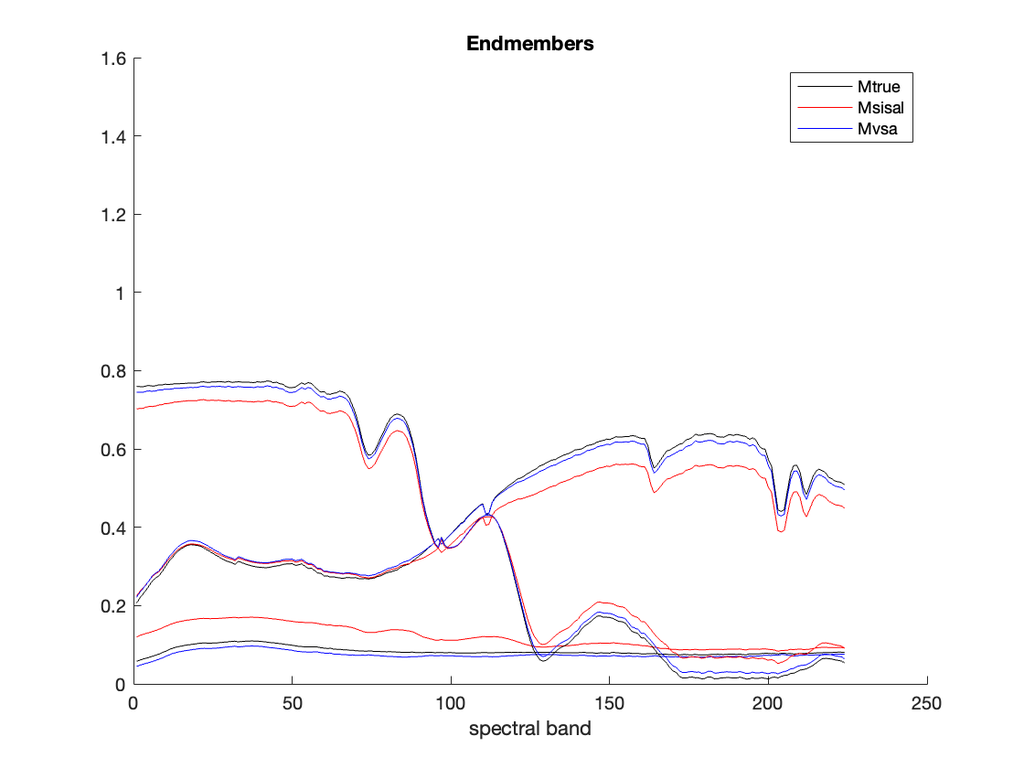

```
Error using matlab.ui.Figure/get
Invalid or deleted object.
```

```matlab
%--------------------------------------------------------------------------
%        Plot signatures
%-------------------------------------------------------------------------
% Choose signatures

leg_cell = cell(1);
H_3=figure;
ylim([0 1.6])
hold on
clear p_H;


% plot signatures
p_H(1) = plot(1:L,(Up*Mtrue(:,1))','k');
leg_cell{end} = 'Mtrue';
p_H(2) =plot(1:L,(Up*Msisal(:,1))','r');
leg_cell{end+1} = 'Msisal';
p_H(3) =plot(1:L,(Up*Mvsa(:,1))','b');
leg_cell{end+1} = 'Mvsa';

for i=2:p
    plot(1:L,(Up*Mtrue(:,i))','k');
    plot(1:L,(Up*Msisal(:,i))','r');
    plot(1:L,(Up*Mvsa(:,i))','b');

end

legend(leg_cell)
title('Endmembers')
xlabel('spectral band')

pos2 = get(H_2,'Position');
pos2(1)=50;
pos2(2)=1;
set(H_2,'Position', pos2)

pos3 = get(H_3,'Position');
pos3(1)=600;
pos3(2)=100+400;
set(H_3,'Position', pos3)
```

```matlab
clearvars -except M L %clearing all variables except M and L since they are the only ones reused in succeeding runs
```

## 200 datapoints, 5 outliers

Looking at the endmember evolution for SISAL, it appears that some of the outliers are ignored when updating the endmembers.

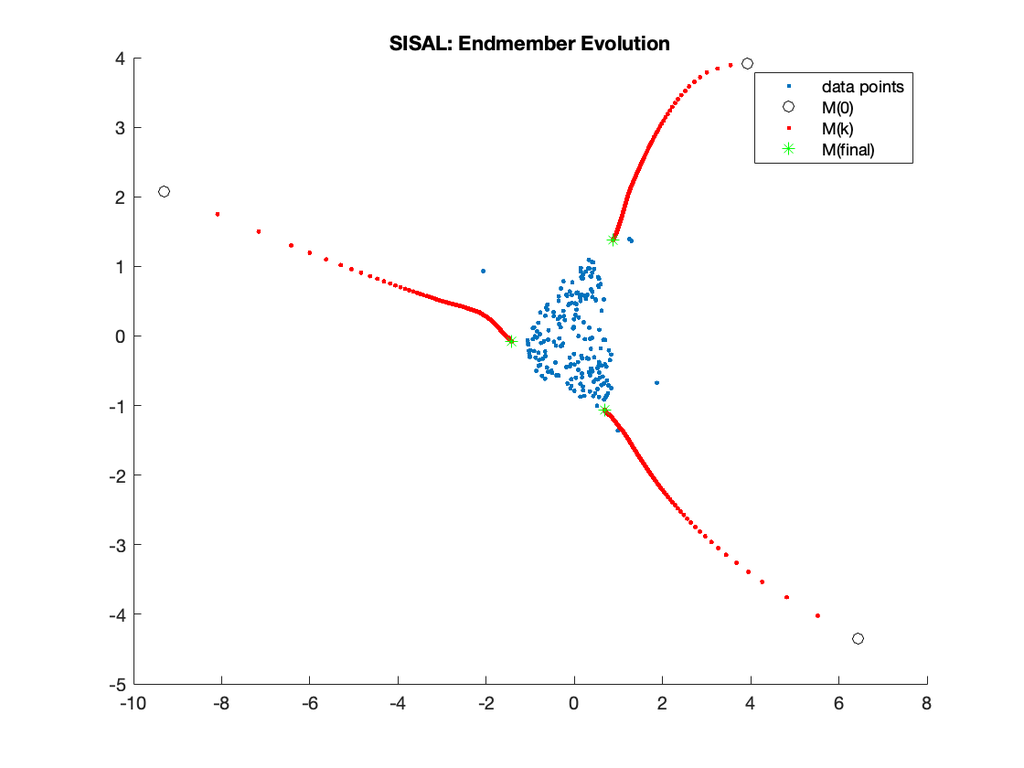

```
SNR estimated = 144.669[dB]
... Select proj. to p-1
SNR estimated = 0[dB]
... Select the projective proj.

 iter = 1, f0 = 4.4240, f = 2.4014, exitflag = 1, iter(QP) = 8

 iter = 2, f0 = 2.4213, f = 2.2855, exitflag = 1, iter(QP) = 8

 iter = 3, f0 = 2.2855, f = 2.2774, exitflag = 1, iter(QP) = 8

 iter: = 3 termination test PASSED

TIMES (sec):
 SISAL = 0.49
 MVSA = 1.94
 VCA = 0.02
```

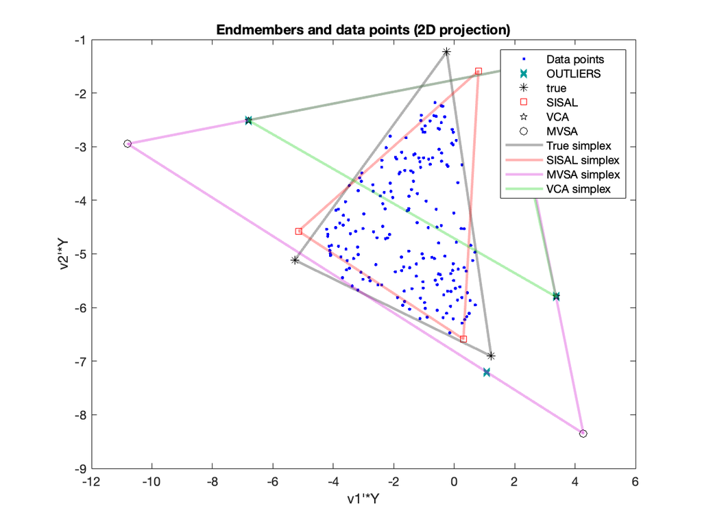

```matlab
seed = 5;                  % Set RNG seed to make results reproducible

p = 3;                    % Number of endmembers
N = 200;                  % number of pixels
SNR = 100;                % signal-to-noise ratio (E ||y||^2/E ||n||^2) in dBs
SHAPE_PARAMETER  = 1   ;  % uniform over the simplex
MAX_PURITY = 0.8;
OUTLIERS  = 5;            % Number of outliers in the data set


% load('USGS_1995_Library')

% M = select_M(datalib, p, 5);
% [L n_materials] = size(datalib);

% clear datalib %Remove loaded dataset

randn('seed',5);

% Generate mixed spectra using the spectMixGen function
[Y,x,noise] = spectMixGen(M,N,'Source_pdf', 'Diri_id','pdf_pars',SHAPE_PARAMETER,...
    'max_purity',MAX_PURITY*ones(1,p),'no_outliers',OUTLIERS, ...
    'violation_extremes',[1,1.2],'snr', SNR, ...
    'noise_shape','uniform');


[Y, Up, my, sing_val] = dataProj(Y,p,'proj_type','affine'); % Project to affine space

%--------------------------------------------------------------------------
%         SISAL[1] -  Simplex identification via split augmented Lagrangian
%-------------------------------------------------------------------------

% start timer
tic
% set the hinge regularization parameter
tau = 0.1;
[A_est] = sisal(Y,p, 'spherize', 'yes','MM_ITERS',40, 'TAU',tau, 'verbose',2);
drawnow;
t(1)=toc;
Msisal =  Up'*A_est;

%--------------------------------------------------------------------------
%         VCA [5] - Vertex component analysis
%-------------------------------------------------------------------------
%
% start timer
tic
[Ae, indice,ys]= VCA(Y,'Endmembers',p);
Mvca = Up'*Ae;
% stop timer
t(2) = toc;

%--------------------------------------------------------------------------
%         MVSA [4] - Minimum volume simple analysis
%-------------------------------------------------------------------------

%start timer
tic

A_est = mvsa(Y,p,'spherize','yes');
Mvsa = Up'*A_est;

%stop timer
t(3) = toc;


%--------------------------------------------------------------------------
%         Project the original mixing matrix and the data set the
%         identified affine set.
%-------------------------------------------------------------------------

Mtrue = Up'*M;
Y = Up'*Y;

%--------------------------------------------------------------------------
%        Display the results
%-------------------------------------------------------------------------

% selects axes  to display
%

I = 1;
J = 2;
K = 3;

% canonical orthogonal directions
E_I = eye(p);

v1 = E_I(:,I);
v2 = E_I(:,J);
v3 = E_I(:,K);

% original axes

Q = inv(Mtrue);
% v1 = Q(I,:)';
% v2 = Q(J,:)';
% v3 = Q(K,:)';

Y = [v1 v2 v3]'*Y;
m_true = [v1 v2 v3]'*Mtrue;
m_sisal = [v1 v2 v3]'*Msisal;


% legend
leg_cell = cell(1);
leg_cell{end} = 'Data points';

H_2 = figure;
plot(Y(1,OUTLIERS+1:end),Y(2,OUTLIERS+1:end),'b.')

hold on;
if OUTLIERS> 0
    plot(Y(1,1:OUTLIERS),Y(2,1:OUTLIERS),'x','Color',[0 0.6 0.6],'LineWidth',3 )
    leg_cell{end +1} = 'OUTLIERS';
end



plot(m_true(1,[1:p 1]), m_true(2,[1:p 1]),'k*')
leg_cell{end +1} = 'true';


plot(m_sisal(1,1:p), m_sisal(2,1:p),'S', 'Color',[1 0 0]) %Plot MVSA endmembers
leg_cell{end +1} = 'SISAL';


m_vca  = [v1 v2 v3]'*Mvca; %Plot VCA endmembers
plot(m_vca(1,[1:p 1]), m_vca(2,[1:p 1]),'p', 'Color',[0  0 0])
leg_cell{end +1} = 'VCA';


m_vsa  = [v1 v2 v3]'*Mvsa; %Plot MVSA endmembers
plot(m_vsa(1,[1:p 1]), m_vsa(2,[1:p 1]),'O','Color',[0 0 0])
leg_cell{end +1} = 'MVSA';


xlabel('v1''*Y'),ylabel('v2''*Y');
legend(leg_cell)
title('Endmembers and data points (2D projection)')

plot(m_true(1,[1:p 1]), m_true(2,[1:p 1]),'k','LineWidth',2, 'DisplayName', 'True simplex', color = [0, 0, 0, 0.3])
plot(m_sisal(1,[1:p 1]), m_sisal(2,[1:p 1]),'r','LineWidth',2, 'DisplayName', 'SISAL simplex', color = [1 0 0 0.3])
plot(m_vsa(1,[1:p 1]), m_vsa(2,[1:p 1]),'LineWidth',2, 'DisplayName', 'MVSA simplex',color = [0.8 0 0.8 0.3])
plot(m_vca(1,[1:p 1]), m_vca(2,[1:p 1]),'LineWidth',2, 'DisplayName', 'VCA simplex',color = [0 0.8 0 0.3])

fprintf('\nTIMES (sec):\n SISAL = %3.2f\n MVSA = %3.2f\n VCA = %3.2f\n', t(1),t(3),t(2))

function M = select_M(datalib, p, seed)  % Select endmember spectra from data
    rand('seed',seed);

    wavlen=datalib(:,1);    % Wavelengths in microns
    [L n_materials]=size(datalib);
        % select randomly
    sel_mat = 4 + randperm(n_materials-4); %Shuffle indices starting from the 4th column
    sel_mat = sel_mat(1:p); % Select first p items in the shuffled indices

    M = datalib(:,sel_mat);

    clear  wavlen

end
```

### Endmember extraction results for SISAL and MVSA (200 points, 5 outliers)

Just by adding 5 outliers, we can already see how `MVSA`’s estimated endmembers are affected by the outliers. In the readings, it is mentioned that most VolMin algorithms are susceptible to outliers. From visual inspection, `SISAL`’s simplex looks the closest to the simplex formed by the true endmembers. We can see in this example that `MVSA` tries to include all the points in the simplex.

### Run times

MVSA is still the slowest of the three algorithms.

### Error (MSE)

Looking at the MSE, it’s surprising that MVSA has smaller MSE even if SISAL has the closer looking simplex. VCA has the highest MSE among the three methods.

```matlab
%--------------------------------------------------------------------------
%        Display errors
%-------------------------------------------------------------------------

%% alignament
% soft

angles = Mtrue'*Msisal./(repmat(sqrt(sum(Mtrue.^2)),p,1)'.*(repmat(sqrt(sum(Msisal.^2)),p,1)));
P = zeros(p);
for i=1:p
    [dummy,j] = max(angles(i,:));
    P(j,i) = 1;
    angles(:,j) = -inf;
end
% permute colums
Msisal = Msisal*P;
SISAL_ERR =norm(Mtrue-Msisal,'fro')/norm(Mtrue,'fro');


angles = Mtrue'*Mvca./(repmat(sqrt(sum(Mtrue.^2)),p,1)'.*(repmat(sqrt(sum(Mvca.^2)),p,1)));
P = zeros(p);
for i=1:p
    [dummy,j] = max(angles(i,:));
    P(j,i) = 1;
    angles(:,j) = -inf;
end
% permute colums
Mvca = Mvca*P;

VCA_ERR =norm(Mtrue-Mvca,'fro')/norm(Mtrue,'fro');



angles = Mtrue'*Mvsa./(repmat(sqrt(sum(Mtrue.^2)),p,1)'.*(repmat(sqrt(sum(Mvsa.^2)),p,1)));
P = zeros(p);
for i=1:p
    [dummy,j] = max(angles(i,:));
    P(j,i) = 1;
    angles(:,j) = -inf;
end
% permute colums
Mvsa = Mvsa*P;

MVSA_ERR =norm(Mtrue-Mvsa,'fro')/norm(Mtrue,'fro');

fprintf('\nERROR(MSE): \n SISAL = %f\n MVSA = %f\n VCA = %f\n', SISAL_ERR,MVSA_ERR,VCA_ERR);
```

```
ERROR(MSE):
 SISAL = 0.903419
 MVSA = 0.698305
 VCA = 1.035287
```

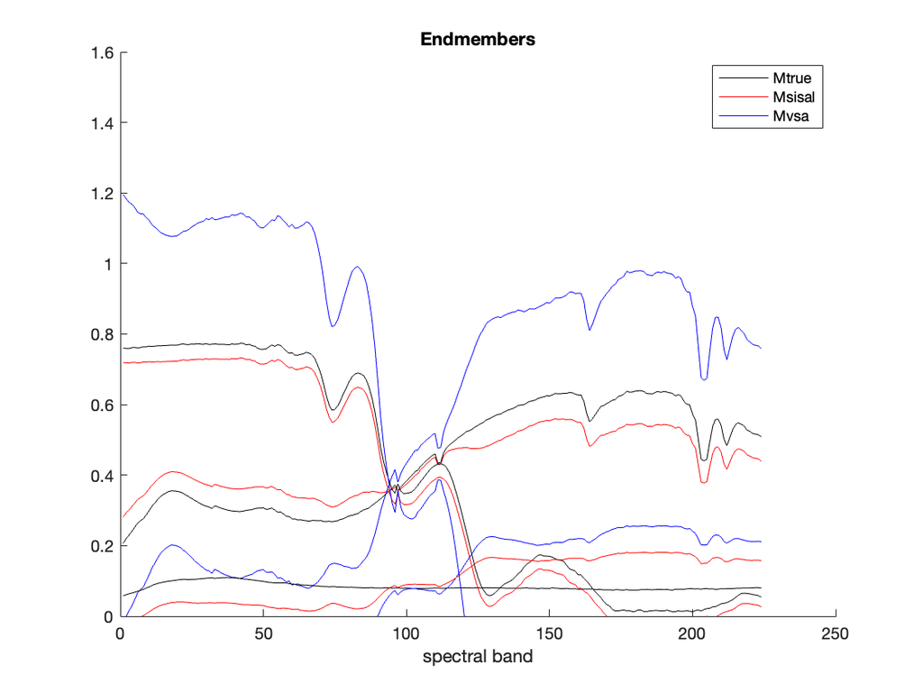

```
Error using matlab.ui.Figure/get
Invalid or deleted object.
```

```matlab
%--------------------------------------------------------------------------
%        Plot signatures
%-------------------------------------------------------------------------
% Choose signatures

leg_cell = cell(1);
H_3=figure;
ylim([0 1.6])
hold on
clear p_H;


% plot signatures
p_H(1) = plot(1:L,(Up*Mtrue(:,1))','k');
leg_cell{end} = 'Mtrue';
p_H(2) =plot(1:L,(Up*Msisal(:,1))','r');
leg_cell{end+1} = 'Msisal';
p_H(3) =plot(1:L,(Up*Mvsa(:,1))','b');
leg_cell{end+1} = 'Mvsa';

for i=2:p
    plot(1:L,(Up*Mtrue(:,i))','k');
    plot(1:L,(Up*Msisal(:,i))','r');
    plot(1:L,(Up*Mvsa(:,i))','b');

end

legend(leg_cell)
title('Endmembers')
xlabel('spectral band')

pos2 = get(H_2,'Position');
pos2(1)=50;
pos2(2)=1;
set(H_2,'Position', pos2)

pos3 = get(H_3,'Position');
pos3(1)=600;
pos3(2)=100+400;
set(H_3,'Position', pos3)
```

### Endmember spectra (200 datapoints, 5 outliers)

Visually, we can see that the SISAL’s endmember spectra follows the spectra of the true endmembers (black and red lines).

## 200 datapoints, 10 outliers

Similar to the 5 outlier case, we see that SISAL seems to not include all points in its simplex.

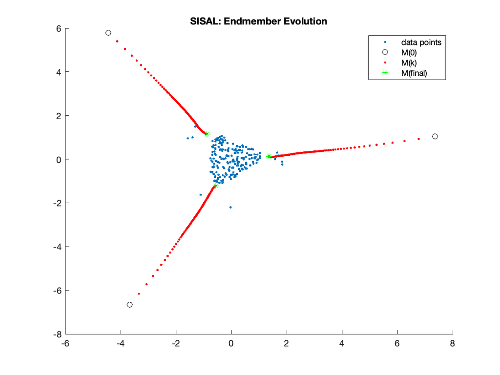

```
SNR estimated = 148.087[dB]
... Select proj. to p-1
SNR estimated = 0[dB]
... Select the projective proj.

 iter = 1, f0 = 4.4175, f = 2.3397, exitflag = 1, iter(QP) = 7

 iter = 2, f0 = 2.3397, f = 2.2773, exitflag = 1, iter(QP) = 8

 iter = 3, f0 = 2.2972, f = 2.2773, exitflag = 1, iter(QP) = 8

 iter: = 3 termination test PASSED

TIMES (sec):
 SISAL = 0.50
 MVSA = 1.84
 VCA = 0.03
```

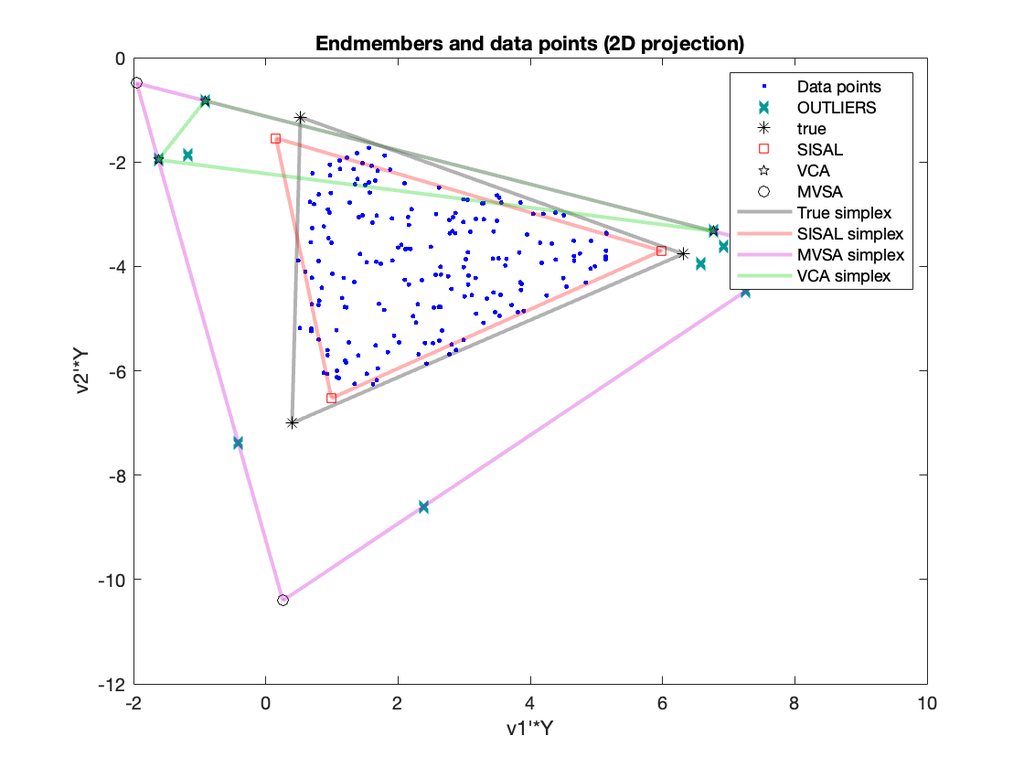

```matlab
seed = 5;                  % Set RNG seed to make results reproducible

p = 3;                    % Number of endmembers
N = 200;                  % number of pixels
SNR = 100;                % signal-to-noise ratio (E ||y||^2/E ||n||^2) in dBs
SHAPE_PARAMETER  = 1   ;  % uniform over the simplex
MAX_PURITY = 0.8;
OUTLIERS  = 10;            % Number of outliers in the data set


randn('seed',5);

% Generate mixed spectra using the spectMixGen function
[Y,x,noise] = spectMixGen(M,N,'Source_pdf', 'Diri_id','pdf_pars',SHAPE_PARAMETER,...
    'max_purity',MAX_PURITY*ones(1,p),'no_outliers',OUTLIERS, ...
    'violation_extremes',[1,1.2],'snr', SNR, ...
    'noise_shape','uniform');


[Y, Up, my, sing_val] = dataProj(Y,p,'proj_type','affine'); % Project to affine space

%--------------------------------------------------------------------------
%         SISAL[1] -  Simplex identification via split augmented Lagrangian
%-------------------------------------------------------------------------

% start timer
tic
% set the hinge regularization parameter
tau = 0.1;
[A_est] = sisal(Y,p, 'spherize', 'yes','MM_ITERS',40, 'TAU',tau, 'verbose',2);
drawnow;
t(1)=toc;
Msisal =  Up'*A_est;

%--------------------------------------------------------------------------
%         VCA [5] - Vertex component analysis
%-------------------------------------------------------------------------
%
% start timer
tic
[Ae, indice,ys]= VCA(Y,'Endmembers',p);
Mvca = Up'*Ae;
% stop timer
t(2) = toc;

%--------------------------------------------------------------------------
%         MVSA [4] - Minimum volume simple analysis
%-------------------------------------------------------------------------

%start timer
tic

A_est = mvsa(Y,p,'spherize','yes');
Mvsa = Up'*A_est;

%stop timer
t(3) = toc;


%--------------------------------------------------------------------------
%         Project the original mixing matrix and the data set the
%         identified affine set.
%-------------------------------------------------------------------------

Mtrue = Up'*M;
Y = Up'*Y;

%--------------------------------------------------------------------------
%        Display the results
%-------------------------------------------------------------------------

% selects axes  to display
%

I = 1;
J = 2;
K = 3;

% canonical orthogonal directions
E_I = eye(p);

v1 = E_I(:,I);
v2 = E_I(:,J);
v3 = E_I(:,K);

% original axes

Q = inv(Mtrue);
% v1 = Q(I,:)';
% v2 = Q(J,:)';
% v3 = Q(K,:)';

Y = [v1 v2 v3]'*Y;
m_true = [v1 v2 v3]'*Mtrue;
m_sisal = [v1 v2 v3]'*Msisal;


% legend
leg_cell = cell(1);
leg_cell{end} = 'Data points';

H_2 = figure;
plot(Y(1,OUTLIERS+1:end),Y(2,OUTLIERS+1:end),'b.')

hold on;
if OUTLIERS> 0
    plot(Y(1,1:OUTLIERS),Y(2,1:OUTLIERS),'x','Color',[0 0.6 0.6],'LineWidth',3 )
    leg_cell{end +1} = 'OUTLIERS';
end



plot(m_true(1,[1:p 1]), m_true(2,[1:p 1]),'k*')
leg_cell{end +1} = 'true';


plot(m_sisal(1,1:p), m_sisal(2,1:p),'S', 'Color',[1 0 0]) %Plot MVSA endmembers
leg_cell{end +1} = 'SISAL';


m_vca  = [v1 v2 v3]'*Mvca; %Plot VCA endmembers
plot(m_vca(1,[1:p 1]), m_vca(2,[1:p 1]),'p', 'Color',[0  0 0])
leg_cell{end +1} = 'VCA';


m_vsa  = [v1 v2 v3]'*Mvsa; %Plot MVSA endmembers
plot(m_vsa(1,[1:p 1]), m_vsa(2,[1:p 1]),'O','Color',[0 0 0])
leg_cell{end +1} = 'MVSA';


xlabel('v1''*Y'),ylabel('v2''*Y');
legend(leg_cell)
title('Endmembers and data points (2D projection)')

plot(m_true(1,[1:p 1]), m_true(2,[1:p 1]),'k','LineWidth',2, 'DisplayName', 'True simplex', color = [0, 0, 0, 0.3])
plot(m_sisal(1,[1:p 1]), m_sisal(2,[1:p 1]),'r','LineWidth',2, 'DisplayName', 'SISAL simplex', color = [1 0 0 0.3])
plot(m_vsa(1,[1:p 1]), m_vsa(2,[1:p 1]),'LineWidth',2, 'DisplayName', 'MVSA simplex',color = [0.8 0 0.8 0.3])
plot(m_vca(1,[1:p 1]), m_vca(2,[1:p 1]),'LineWidth',2, 'DisplayName', 'VCA simplex',color = [0 0.8 0 0.3])

fprintf('\nTIMES (sec):\n SISAL = %3.2f\n MVSA = %3.2f\n VCA = %3.2f\n', t(1),t(3),t(2))

function M = select_M(datalib, p, seed)  % Select endmember spectra from data
    rand('seed',seed);

    wavlen=datalib(:,1);    % Wavelengths in microns
    [L n_materials]=size(datalib);
        % select randomly
    sel_mat = 4 + randperm(n_materials-4); %Shuffle indices starting from the 4th column
    sel_mat = sel_mat(1:p); % Select first p items in the shuffled indices

    M = datalib(:,sel_mat);

    clear  wavlen

end
```

### Endmember extraction results for SISAL and MVSA (200 points, 10 outliers)

For 10 outliers, we can still see that `MVSA`’s estimated endmembers tries to include all the points in its simplex. SISAL still has the closest looking simplex to the true endmembers.

### Run times

Again, MVSA is still the slowest of the three algorithms.

### Error (MSE)

SISAL now has the smallest MSE.

```matlab
%--------------------------------------------------------------------------
%        Display errors
%-------------------------------------------------------------------------

%% alignament
% soft

angles = Mtrue'*Msisal./(repmat(sqrt(sum(Mtrue.^2)),p,1)'.*(repmat(sqrt(sum(Msisal.^2)),p,1)));
P = zeros(p);
for i=1:p
    [dummy,j] = max(angles(i,:));
    P(j,i) = 1;
    angles(:,j) = -inf;
end
% permute colums
Msisal = Msisal*P;
SISAL_ERR =norm(Mtrue-Msisal,'fro')/norm(Mtrue,'fro');


angles = Mtrue'*Mvca./(repmat(sqrt(sum(Mtrue.^2)),p,1)'.*(repmat(sqrt(sum(Mvca.^2)),p,1)));
P = zeros(p);
for i=1:p
    [dummy,j] = max(angles(i,:));
    P(j,i) = 1;
    angles(:,j) = -inf;
end
% permute colums
Mvca = Mvca*P;

VCA_ERR =norm(Mtrue-Mvca,'fro')/norm(Mtrue,'fro');



angles = Mtrue'*Mvsa./(repmat(sqrt(sum(Mtrue.^2)),p,1)'.*(repmat(sqrt(sum(Mvsa.^2)),p,1)));
P = zeros(p);
for i=1:p
    [dummy,j] = max(angles(i,:));
    P(j,i) = 1;
    angles(:,j) = -inf;
end
% permute colums
Mvsa = Mvsa*P;

MVSA_ERR =norm(Mtrue-Mvsa,'fro')/norm(Mtrue,'fro');

fprintf('\nERROR(mse): \n SISAL = %f\n MVSA = %f\n VCA = %f\n', SISAL_ERR,MVSA_ERR,VCA_ERR);
```

```
ERROR(mse):
 SISAL = 0.751408
 MVSA = 1.215216
 VCA = 1.131310
```

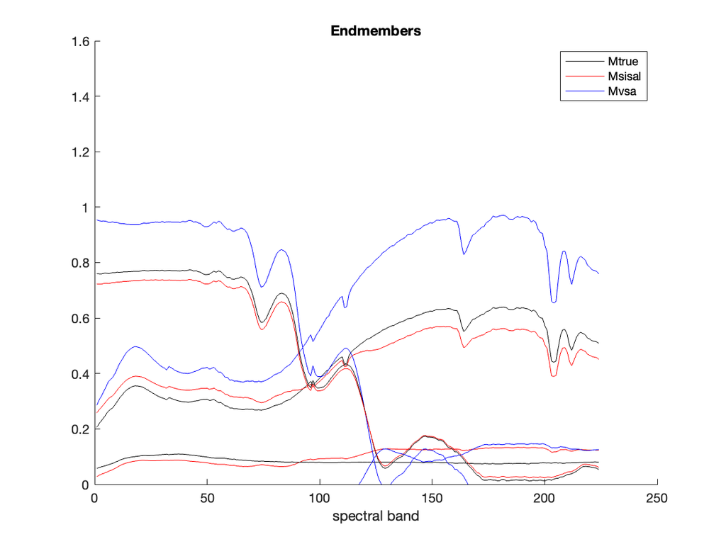

```
Error using matlab.ui.Figure/get
Invalid or deleted object.
```

```matlab
%--------------------------------------------------------------------------
%        Plot signatures
%-------------------------------------------------------------------------
% Choose signatures

leg_cell = cell(1);
H_3=figure;
ylim([0 1.6])
hold on
clear p_H;


% plot signatures
p_H(1) = plot(1:L,(Up*Mtrue(:,1))','k');
leg_cell{end} = 'Mtrue';
p_H(2) =plot(1:L,(Up*Msisal(:,1))','r');
leg_cell{end+1} = 'Msisal';
p_H(3) =plot(1:L,(Up*Mvsa(:,1))','b');
leg_cell{end+1} = 'Mvsa';

for i=2:p
    plot(1:L,(Up*Mtrue(:,i))','k');
    plot(1:L,(Up*Msisal(:,i))','r');
    plot(1:L,(Up*Mvsa(:,i))','b');

end

legend(leg_cell)
title('Endmembers')
xlabel('spectral band')

pos2 = get(H_2,'Position');
pos2(1)=50;
pos2(2)=1;
set(H_2,'Position', pos2)

pos3 = get(H_3,'Position');
pos3(1)=600;
pos3(2)=100+400;
set(H_3,'Position', pos3)
```

```matlab
clearvars -except M L %clearing all variables except M and L since they are the only ones reused in succeeding runs
```

## 200 datapoints, 20 outliers

With $\frac{1}{10}$ of the data being outliers, we see that the SISAL still has most of the data in the simplex.

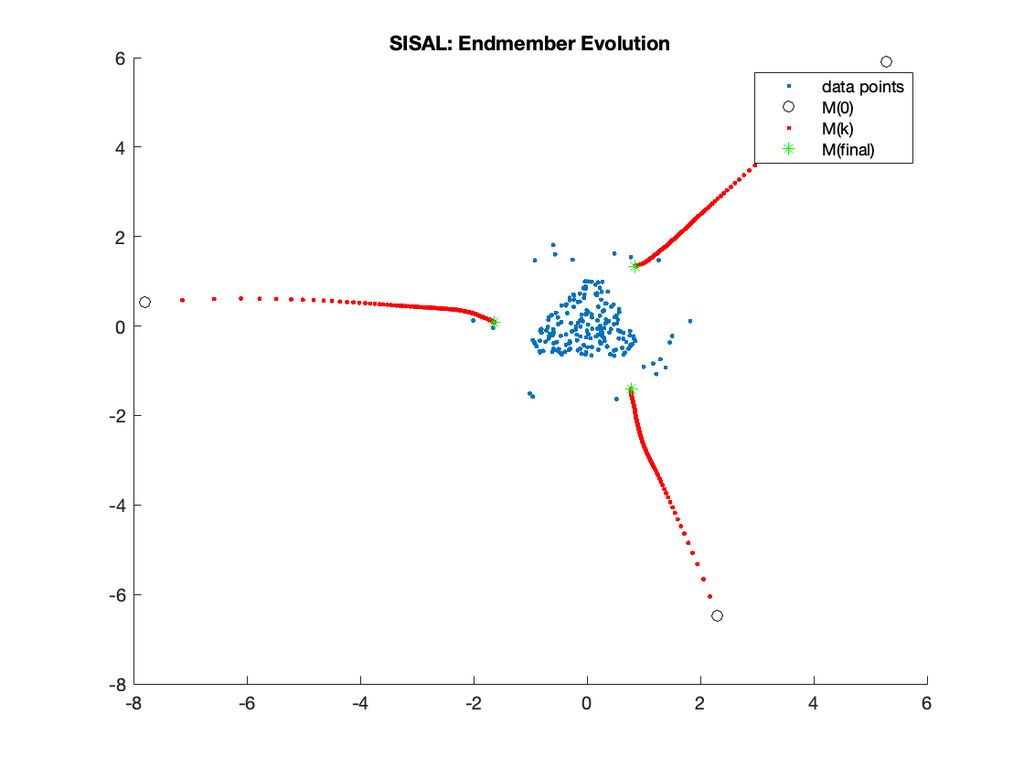

```
SNR estimated = 145.943[dB]
... Select proj. to p-1
SNR estimated = 0[dB]
... Select the projective proj.

 iter = 1, f0 = 4.3986, f = 2.9962, exitflag = 1, iter(QP) = 7

 iter = 2, f0 = 2.9962, f = 2.8580, exitflag = 1, iter(QP) = 9

 iter = 3, f0 = 2.8779, f = 2.8336, exitflag = 1, iter(QP) = 7

 iter: = 3 termination test PASSED

TIMES (sec):
 SISAL = 0.45
 MVSA = 1.92
 VCA = 0.03
```

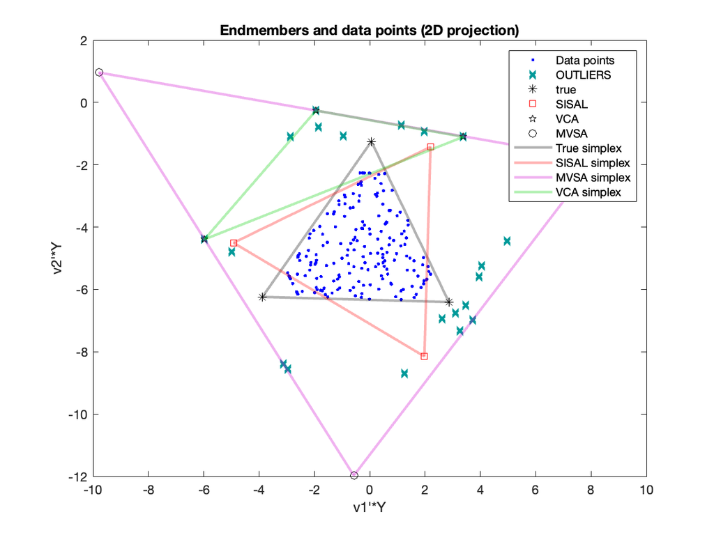

```matlab
seed = 5;                  % Set RNG seed to make results reproducible

p = 3;                    % Number of endmembers
N = 200;                  % number of pixels
SNR = 100;                % signal-to-noise ratio (E ||y||^2/E ||n||^2) in dBs
SHAPE_PARAMETER  = 1   ;  % uniform over the simplex
MAX_PURITY = 0.8;
OUTLIERS  = 20;            % Number of outliers in the data set


randn('seed',5);

% Generate mixed spectra using the spectMixGen function
[Y,x,noise] = spectMixGen(M,N,'Source_pdf', 'Diri_id','pdf_pars',SHAPE_PARAMETER,...
    'max_purity',MAX_PURITY*ones(1,p),'no_outliers',OUTLIERS, ...
    'violation_extremes',[1,1.2],'snr', SNR, ...
    'noise_shape','uniform');


[Y, Up, my, sing_val] = dataProj(Y,p,'proj_type','affine'); % Project to affine space

%--------------------------------------------------------------------------
%         SISAL[1] -  Simplex identification via split augmented Lagrangian
%-------------------------------------------------------------------------

% start timer
tic
% set the hinge regularization parameter
tau = 0.1;
[A_est] = sisal(Y,p, 'spherize', 'yes','MM_ITERS',40, 'TAU',tau, 'verbose',2);
drawnow;
t(1)=toc;
Msisal =  Up'*A_est;

%--------------------------------------------------------------------------
%         VCA [5] - Vertex component analysis
%-------------------------------------------------------------------------
%
% start timer
tic
[Ae, indice,ys]= VCA(Y,'Endmembers',p);
Mvca = Up'*Ae;
% stop timer
t(2) = toc;

%--------------------------------------------------------------------------
%         MVSA [4] - Minimum volume simple analysis
%-------------------------------------------------------------------------

%start timer
tic

A_est = mvsa(Y,p,'spherize','yes');
Mvsa = Up'*A_est;

%stop timer
t(3) = toc;


%--------------------------------------------------------------------------
%         Project the original mixing matrix and the data set the
%         identified affine set.
%-------------------------------------------------------------------------

Mtrue = Up'*M;
Y = Up'*Y;

%--------------------------------------------------------------------------
%        Display the results
%-------------------------------------------------------------------------

% selects axes  to display
%

I = 1;
J = 2;
K = 3;

% canonical orthogonal directions
E_I = eye(p);

v1 = E_I(:,I);
v2 = E_I(:,J);
v3 = E_I(:,K);

% original axes

Q = inv(Mtrue);
% v1 = Q(I,:)';
% v2 = Q(J,:)';
% v3 = Q(K,:)';

Y = [v1 v2 v3]'*Y;
m_true = [v1 v2 v3]'*Mtrue;
m_sisal = [v1 v2 v3]'*Msisal;


% legend
leg_cell = cell(1);
leg_cell{end} = 'Data points';

H_2 = figure;
plot(Y(1,OUTLIERS+1:end),Y(2,OUTLIERS+1:end),'b.')

hold on;
if OUTLIERS> 0
    plot(Y(1,1:OUTLIERS),Y(2,1:OUTLIERS),'x','Color',[0 0.6 0.6],'LineWidth',3 )
    leg_cell{end +1} = 'OUTLIERS';
end



plot(m_true(1,[1:p 1]), m_true(2,[1:p 1]),'k*')
leg_cell{end +1} = 'true';


plot(m_sisal(1,1:p), m_sisal(2,1:p),'S', 'Color',[1 0 0]) %Plot MVSA endmembers
leg_cell{end +1} = 'SISAL';


m_vca  = [v1 v2 v3]'*Mvca; %Plot VCA endmembers
plot(m_vca(1,[1:p 1]), m_vca(2,[1:p 1]),'p', 'Color',[0  0 0])
leg_cell{end +1} = 'VCA';


m_vsa  = [v1 v2 v3]'*Mvsa; %Plot MVSA endmembers
plot(m_vsa(1,[1:p 1]), m_vsa(2,[1:p 1]),'O','Color',[0 0 0])
leg_cell{end +1} = 'MVSA';


xlabel('v1''*Y'),ylabel('v2''*Y');
legend(leg_cell)
title('Endmembers and data points (2D projection)')

plot(m_true(1,[1:p 1]), m_true(2,[1:p 1]),'k','LineWidth',2, 'DisplayName', 'True simplex', color = [0, 0, 0, 0.3])
plot(m_sisal(1,[1:p 1]), m_sisal(2,[1:p 1]),'r','LineWidth',2, 'DisplayName', 'SISAL simplex', color = [1 0 0 0.3])
plot(m_vsa(1,[1:p 1]), m_vsa(2,[1:p 1]),'LineWidth',2, 'DisplayName', 'MVSA simplex',color = [0.8 0 0.8 0.3])
plot(m_vca(1,[1:p 1]), m_vca(2,[1:p 1]),'LineWidth',2, 'DisplayName', 'VCA simplex',color = [0 0.8 0 0.3])

fprintf('\nTIMES (sec):\n SISAL = %3.2f\n MVSA = %3.2f\n VCA = %3.2f\n', t(1),t(3),t(2))

function M = select_M(datalib, p, seed)  % Select endmember spectra from data
    rand('seed',seed);

    wavlen=datalib(:,1);    % Wavelengths in microns
    [L n_materials]=size(datalib);
        % select randomly
    sel_mat = 4 + randperm(n_materials-4); %Shuffle indices starting from the 4th column
    sel_mat = sel_mat(1:p); % Select first p items in the shuffled indices

    M = datalib(:,sel_mat);

    clear  wavlen

end
```

### Endmember extraction results for SISAL and MVSA (200 points, 20 outliers)

Even with 20 outliers, `MVSA`’s estimated endmembers still tries to include all the points in its simplex. SISAL’s simplex captures most of the data points, but it looks rotated compared to the true endmember simplex. VCA just captures the outliers at this point

### Run times

Again, MVSA is still the slowest of the three algorithms.

### Error (MSE)

SISAL still has the smallest MSE, but it is close to 1. This is likely due to the apparent rotation in the simplex.

```matlab
%--------------------------------------------------------------------------
%        Display errors
%-------------------------------------------------------------------------

%% alignament
% soft

angles = Mtrue'*Msisal./(repmat(sqrt(sum(Mtrue.^2)),p,1)'.*(repmat(sqrt(sum(Msisal.^2)),p,1)));
P = zeros(p);
for i=1:p
    [dummy,j] = max(angles(i,:));
    P(j,i) = 1;
    angles(:,j) = -inf;
end
% permute colums
Msisal = Msisal*P;
SISAL_ERR =norm(Mtrue-Msisal,'fro')/norm(Mtrue,'fro');


angles = Mtrue'*Mvca./(repmat(sqrt(sum(Mtrue.^2)),p,1)'.*(repmat(sqrt(sum(Mvca.^2)),p,1)));
P = zeros(p);
for i=1:p
    [dummy,j] = max(angles(i,:));
    P(j,i) = 1;
    angles(:,j) = -inf;
end
% permute colums
Mvca = Mvca*P;

VCA_ERR =norm(Mtrue-Mvca,'fro')/norm(Mtrue,'fro');



angles = Mtrue'*Mvsa./(repmat(sqrt(sum(Mtrue.^2)),p,1)'.*(repmat(sqrt(sum(Mvsa.^2)),p,1)));
P = zeros(p);
for i=1:p
    [dummy,j] = max(angles(i,:));
    P(j,i) = 1;
    angles(:,j) = -inf;
end
% permute colums
Mvsa = Mvsa*P;

MVSA_ERR =norm(Mtrue-Mvsa,'fro')/norm(Mtrue,'fro');

fprintf('\nERROR(mse): \n SISAL = %f\n MVSA = %f\n VCA = %f\n', SISAL_ERR,MVSA_ERR,VCA_ERR);
```

```
ERROR(mse):
 SISAL = 0.973392
 MVSA = 1.364809
 VCA = 1.043120
```

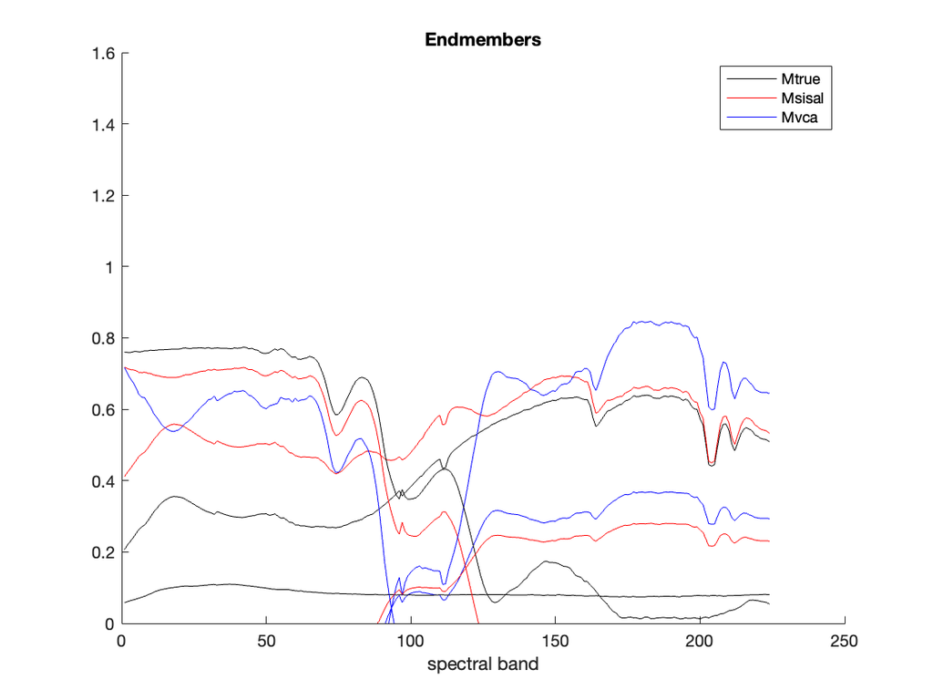

```
Error using matlab.ui.Figure/get
Invalid or deleted object.
```

```matlab
%--------------------------------------------------------------------------
%        Plot signatures
%-------------------------------------------------------------------------
% Choose signatures

leg_cell = cell(1);
H_3=figure;
ylim([0 1.6])
hold on
clear p_H;


% plot signatures
p_H(1) = plot(1:L,(Up*Mtrue(:,1))','k');
leg_cell{end} = 'Mtrue';
p_H(2) =plot(1:L,(Up*Msisal(:,1))','r');
leg_cell{end+1} = 'Msisal';
p_H(3) =plot(1:L,(Up*Mvca(:,1))','b');
leg_cell{end+1} = 'Mvca';

for i=2:p
    plot(1:L,(Up*Mtrue(:,i))','k');
    plot(1:L,(Up*Msisal(:,i))','r');
    plot(1:L,(Up*Mvsa(:,i))','b');

end

legend(leg_cell)
title('Endmembers')
xlabel('spectral band')

pos2 = get(H_2,'Position');
pos2(1)=50;
pos2(2)=1;
set(H_2,'Position', pos2)

pos3 = get(H_3,'Position');
pos3(1)=600;
pos3(2)=100+400;
set(H_3,'Position', pos3)
```

```matlab
clearvars -except M, L
```

```
Unrecognized function or variable 'L'.
```

## Key takeaways

- SISAL is robust to outliers, as seen its estimated endmembers covering most of the dataset.
- MVSA performed well without outliers, but fails to capture the data points when outliers are present. MVSA tries to fit all the points in the space into its simplex.
- VCA, being a pure pixel algorithm, fails to make good endmember estimations when outliers are present.

## Pitfalls

Ideally, these algorithms should be run multiple times to make any generalizations. The results here do follow what’s describe in the readings for hyperspectral unmixing. Existing MATLAB codes compiled by Uri Alon’s lab provide other great examples to explore in the future to get a better familiarity of the methods.

## References

[1]

J. Li and J. M. Bioucas-Dias, “Minimum volume simplex analysis: A fast algorithm to unmix hyperspectral data,” *IGARSS 2008 - 2008 IEEE International Geoscience and Remote Sensing Symposium*, vol. 3, pp. III - 250-III - 253, 2008.

[2]

J. M. Bioucas-Dias, “A variable splitting augmented lagrangian approach to linear spectral unmixing,” in *2009 First workshop on hyperspectral image and signal processing: Evolution in remote sensing*, IEEE, 2009, pp. 1–4.

[3]

U. Alon, “Pareto task inference (ParTi) method,” *Uri Alon*. Mar. 2022. Available: https://www.weizmann.ac.il/mcb/UriAlon/download/ParTI